# Testing atlantisom: do we ever get small fish in length comps?

Sarah Gaichas and Christine Stawitz

15 May, 2019

## Introduction

Here we further test the function `calc_age2length` to see if small fish ever appear with full census sampling. If they don’t, perhaps the default CV in the function needs modification? This question is triggered by the [sampling for NOBA Greenland halibut](https://sgaichas.github.io/poseidon-dev/NOBAStdSurvLengthCompTest.html), in which fish below 50 cm didn’t show up.

For all setup, etc, please see previous files Full methods are explained [here](https://sgaichas.github.io/poseidon-dev/TrueBioTest.html) and [here](https://sgaichas.github.io/poseidon-dev/TrueLengthCompTest.html).

This page has visualizations for the NOBA model example, CERES Global Sustainability. For full explanation of methods, see the file linked at the beginning of each section.

## Simulate a survey part 4: sample for length composition (testing revised function)

Full methods are explained [here](https://sgaichas.github.io/poseidon-dev/StdSurvLengthCompTest.html).

We will apply examples here to only one species, Greenland halibut in NOBA, which grows to a large size.

To create a census, the user specifies the timing of the survey, which species are captured, the spatial coverage of the survey, the species-specific survey efficiency (“q”), and the selectivity at age for each species. The following settings should achieve a survey that samples all Atlantis model output timesteps, all fish and shark species, and all model polygons, with perfect efficiency and full selectivity for all ages.

Here we use `create_survey` on the numbers output of `run_truth` to create the survey census of age composition (for just one species in this case). The `sample_fish` applies the median for aggregation and does not apply multinomial sampling if `sample=FALSE` in the function call.

Because we don’t want to wait 24 hours for this, we will look at only the first 112 time steps.

```r
ss.name <- funct.group.names[funct.group.names == "Green_halibut"]

# get survey nums with full (no) selectivity
ss_survey_testNall <- create_survey(dat = truth$nums,
                                 time = c(0:111),
                                 species = ss.name,
                                 boxes = boxall,
                                 effic = effic1,
                                 selex = selex1)

# this one is high but not equal to total for numerous groups
effNhigh <- data.frame(species=survspp, effN=rep(1e+8, length(survspp)))

# apply default sample fish as before to get numbers
ss_numsallhigh <- sample_fish(ss_survey_testNall, effNhigh)


# aggregate true resn per survey design
ss_aggresnall <- aggregateDensityData(dat = truth$resn,
                                 time = c(0:111),
                                 species = ss.name,
                                 boxes = boxall)

# aggregate true structn per survey design
ss_aggstructnall <- aggregateDensityData(dat = truth$structn,
                                 time = c(0:111),
                                 species = ss.name,
                                 boxes = boxall)

#dont sample these, just aggregate them using median
ss_structnall <- sample_fish(ss_aggstructnall, effNhigh, sample = FALSE)

ss_resnall <-  sample_fish(ss_aggresnall, effNhigh, sample = FALSE)
```

Length sample with user specified max length bin (200 cm):

```r
ss_length_census <- calc_age2length(structn = ss_structnall,
                                 resn = ss_resnall,
                                 nums = ss_numsallhigh,
                                 biolprm = truth$biolprm, fgs = truth$fgs,
                                 maxbin = 200,
                                 CVlenage = 0.1, remove.zeroes=TRUE)
```

We should get the upper end of Greenland halibut with a 200cm max length bin. What I am concerned about here is whether we get very small fish at any time step:

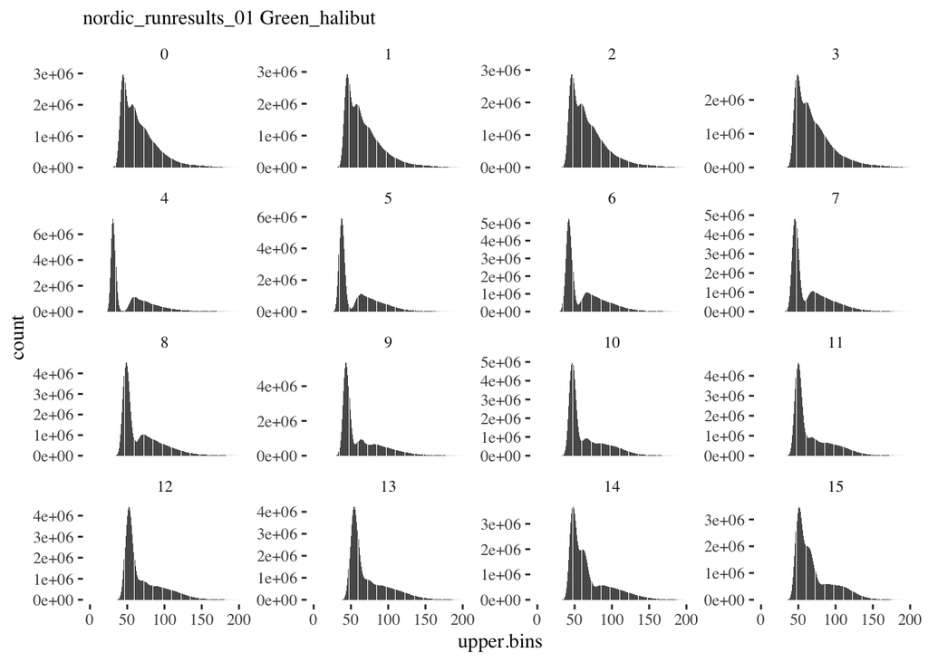

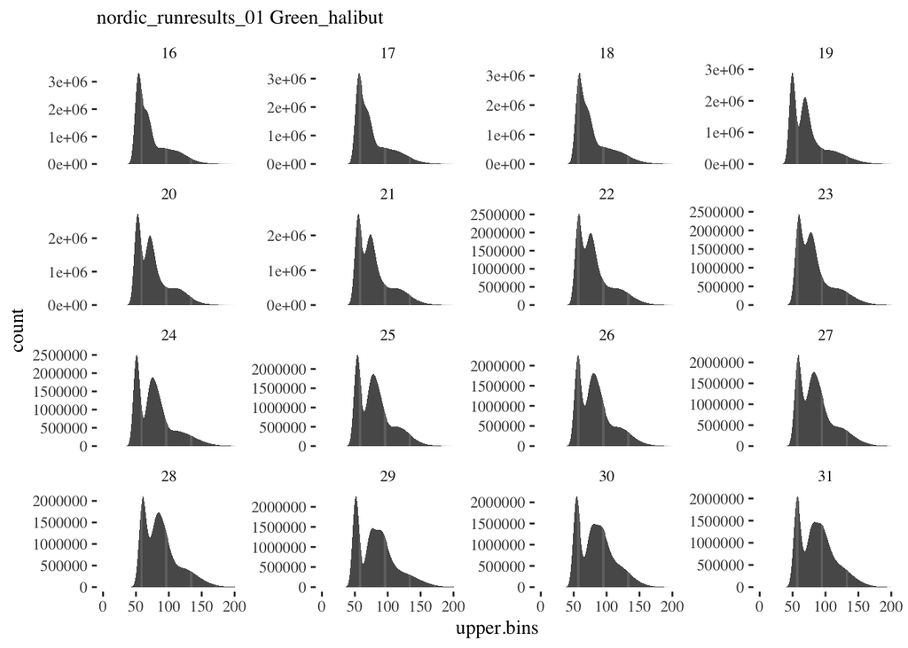

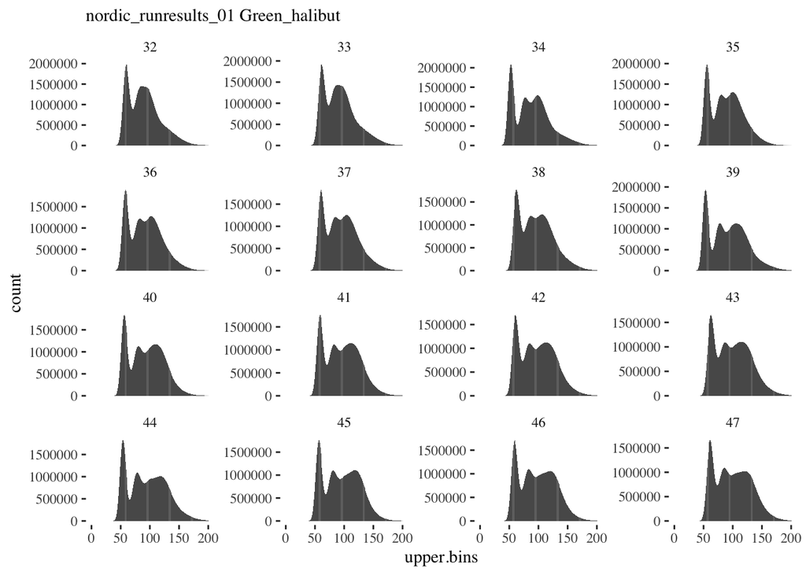

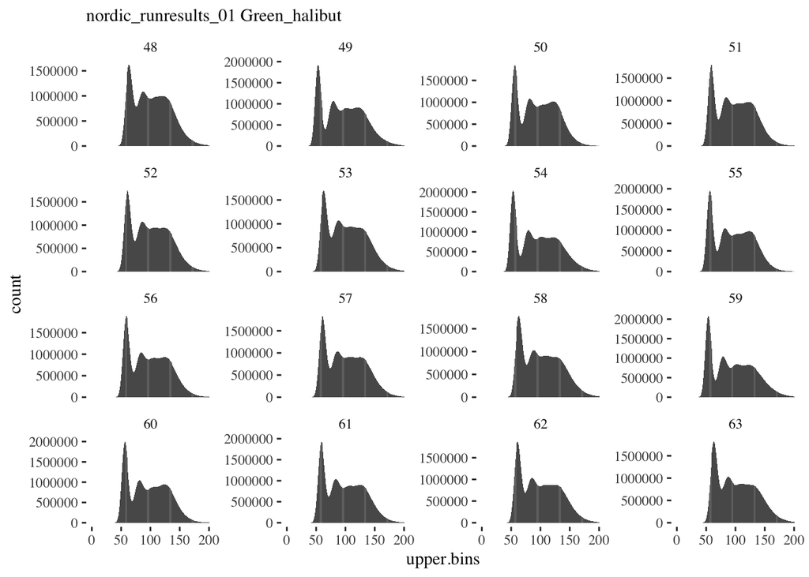

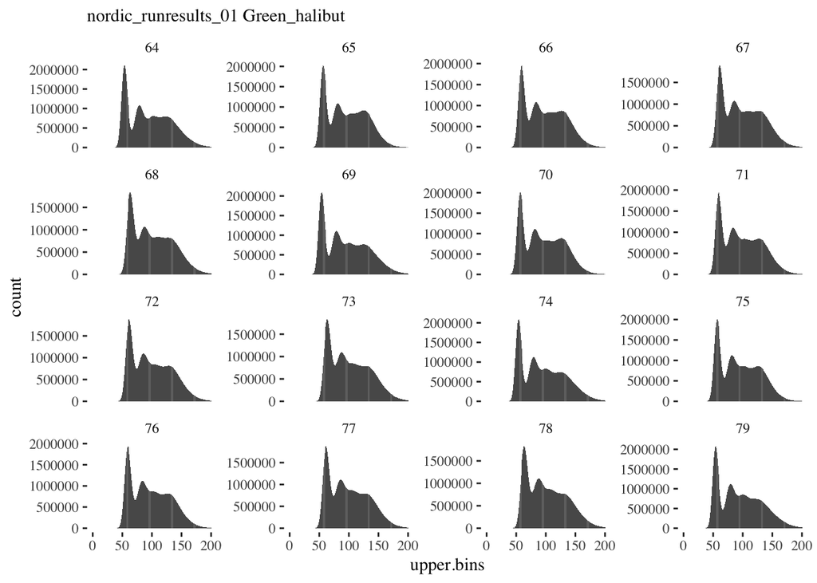

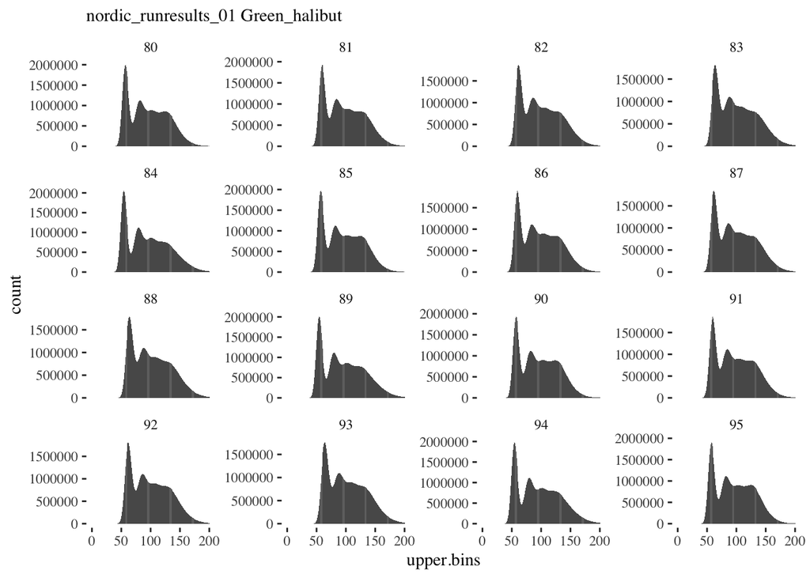

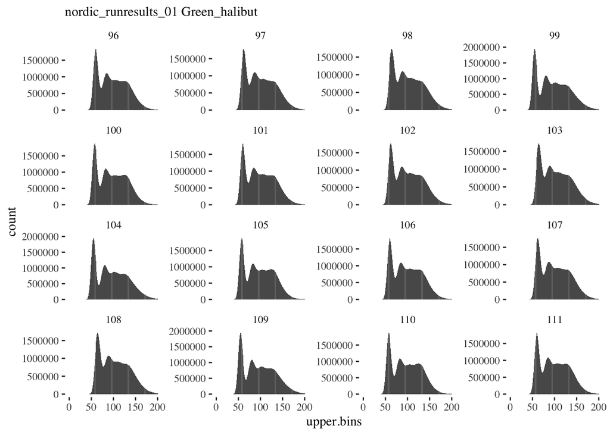

Are there fish <50 cm long at any output timestep? If not, does this make sense? There appear to be a few, such as timestep 4. Hard to see at this level.

Aggregate length comp over all of these time steps (first 22+ years):

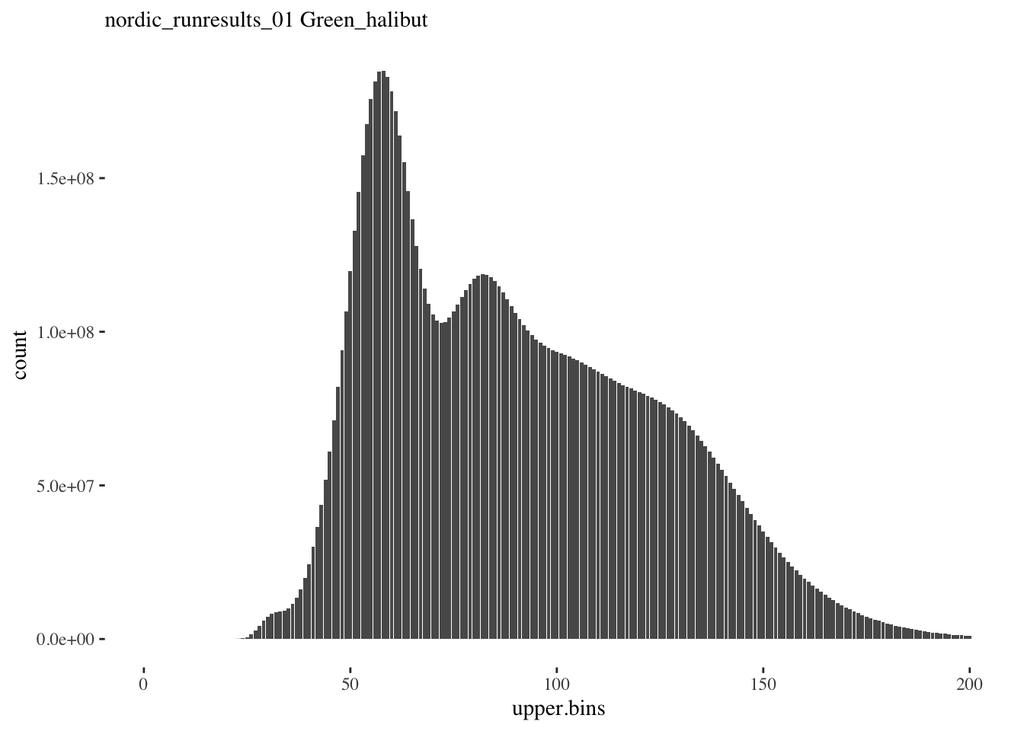

This suggests that the smallest Greenland turbot in the ecosystem are ~25 cm over all of the timesteps we checked. Does this make sense?

## Quick test with saved CCA census output

Here we check the CCA model (Atlantis Summit Common Scenario 1) saved length census output for small species at Isaac’s suggestion:

```r
source(here("config/CCConfig.R"))

length_censussurvsamp <- readRDS(file.path(d.name, paste0(scenario.name, "length_censussurvsamp.rds")))
```

Sardine:

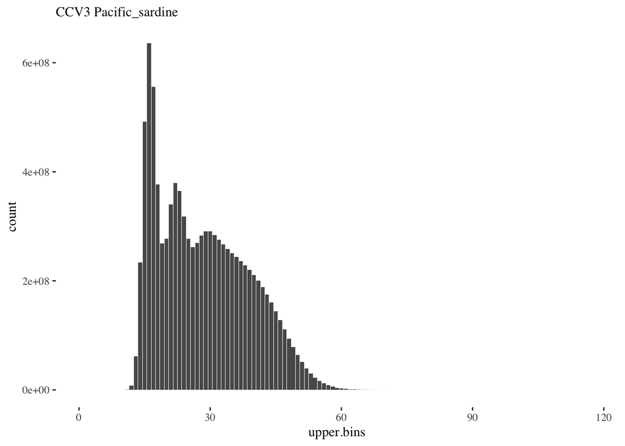

Anchovy:

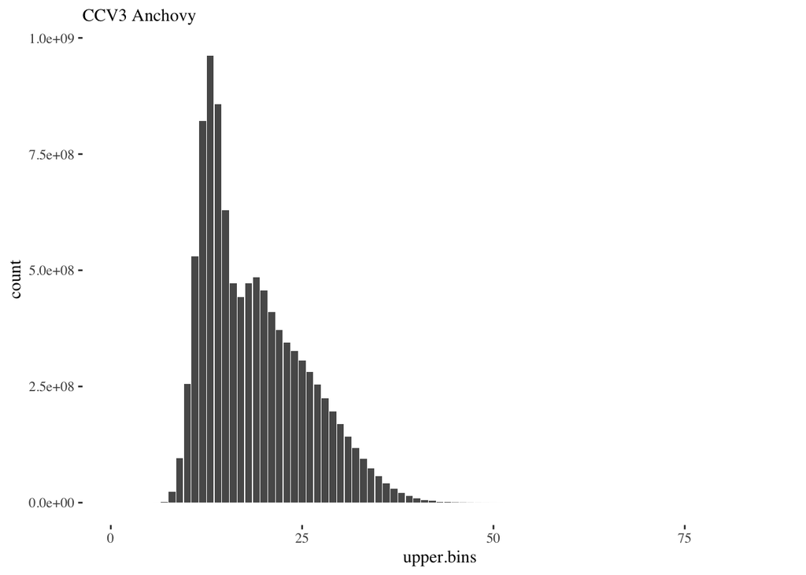

Herring:

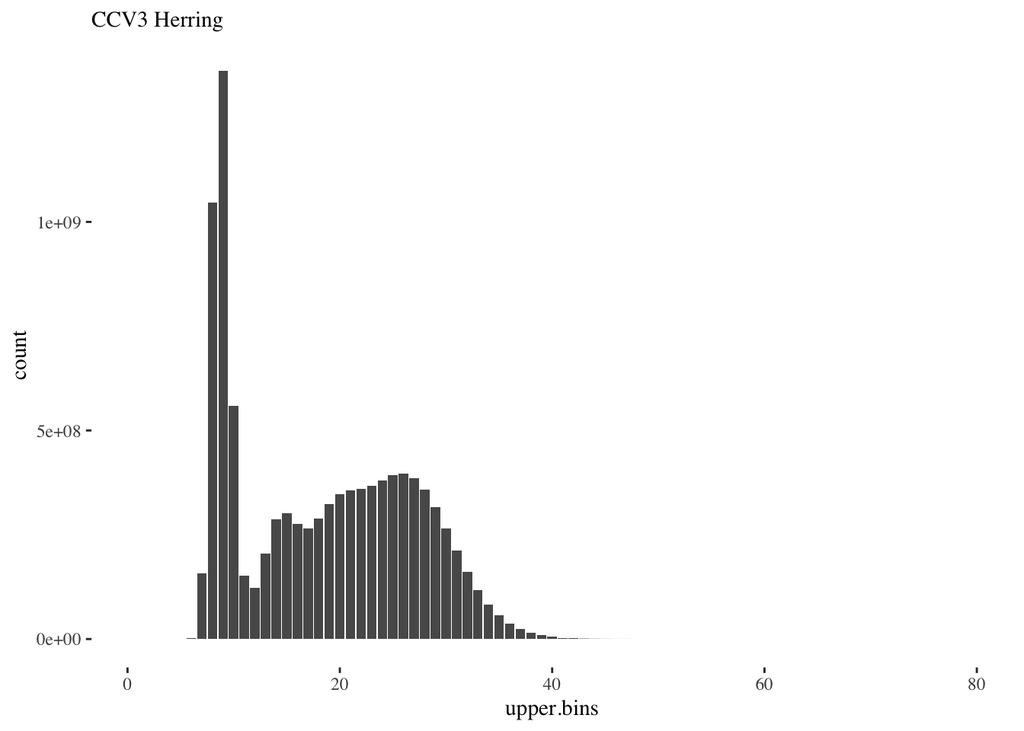

How do these three look?

Do we need to change something about the length comp estimation?